# Reproducible code for the Preamble post - LSI to group books into categories

Eu Jin Lok

26 November 2017

## Preamble post - Latent Semantic Indexing

In this notebook we will go into the details of how to run LSA step by step in code. For the full background on this topic, please checkout the wordpress blog post here: https://mungingdata.wordpress.com/2017/11/26/preamble-lsi-to-group-books-into-categories/

Also note that the results may differ to what is on the blog as I tried to simplify the workings. Here you get the full blown experiment un-tampered

So without further ado, lets begin:

```r
############
# load key libraries
############
#NOTE: R version 3.3.3 (2017-03-06) -- "Another Canoe"
library(tm) #standard text mining processes
library(irlba) #for running fast SVD
library(ggrepel)
set.seed(678)  # ensure the Dimensions are consistent with the blog each time
```

I’m going to construct the toy dataset that was used by the blog post

```r
############
# Read the data
############

# make a toy dataset
a = "Human machine interface for Lab ABC computer applications"
b = "A survey of user opinion of computer system response time"
c = "The EPS user interface management system"
d = "System and human system engineering testing of EPS"
e = "Relation of user-perceived response time to error measurement"
f = "The generation of random, binary, unordered trees"
g = "The intersection graph of paths in trees"
h = "Graph minors IV: Widths of trees and well-quasi-ordering"
i = "Graph minors: A survey"

# coerce the data set into a dataframe
mat = rbind(a,b,c,d,e,f,g,h,i)
mat = data.frame(doc = 1:9,text = mat)
```

Now lets apply some cleaning on the text data

```r
# Apply corpus object and start cleaning the text data
set = Corpus(VectorSource(mat$text))
set = tm_map(set, removeNumbers)
set = tm_map(set, removePunctuation)
set = tm_map(set, content_transformer(tolower))
set = tm_map(set, function(x) removeWords(x, stopwords("english")))
set = tm_map(set, stripWhitespace)

# check the result to ensure its correct
inspect(set[1])
```

```
## <<SimpleCorpus>>
## Metadata:  corpus specific: 1, document level (indexed): 0
## Content:  documents: 1
##
## [1] human machine interface lab abc computer applications
```

The text is much more readable now. So next we’re going to create a DTM object, also known as Document-Term-Matrix. Basically a matrix of documents on rows and terms on columns. Its the native format that is required to LSI (Latent Semantic Indexing) and topic modelling

```r
#convert to DTM
#corpus <- tm_map(corpus, PlainTextDocument)
dtm = DocumentTermMatrix(set)
#check the data
inspect(dtm[1:4, 1:10])
```

```
## <<DocumentTermMatrix (documents: 4, terms: 10)>>
## Non-/sparse entries: 13/27
## Sparsity           : 68%
## Maximal term length: 12
## Weighting          : term frequency (tf)
## Sample             :
##     Terms
## Docs abc applications computer human interface lab machine opinion
##    1   1            1        1     1         1   1       1       0
##    2   0            0        1     0         0   0       0       1
##    3   0            0        0     0         1   0       0       0
##    4   0            0        0     1         0   0       0       0
##     Terms
## Docs response survey
##    1        0      0
##    2        1      1
##    3        0      0
##    4        0      0
```

Notice that the matrix is fairly sparse? This tends to be the case in real life documents, where sparsity is close the 100%. I won’t go into details but a few phenomenon follows similar distribution such as movies watched, our social networks etc. In movies for example, there are hundres of thousands movies made in the world, but any one person will watch less than 10% of the whole list of movies. This phenonmenon can be explained by Zipf’s Law. And because of Zipf’s Law,we will not apply TF-IDF to this example

```r
#check the vocabulary list
colnames(dtm)[1:10]
```

```
##  [1] "abc"          "applications" "computer"     "human"
##  [5] "interface"    "lab"          "machine"      "opinion"
##  [9] "response"     "survey"
```

```r
#save these words as our custom dictionary
Dictionary = colnames(dtm)

#now lets perform an SVD using the irlba package. Lets use 2 dimensions
svd = irlba(as.matrix(dtm),2)

# the U D V components
u = svd$u
d = diag(svd$d)
v = svd$v

# Quiz for those who read this notebook. This part below may look familar. Where is it applied to and what is it commonly know as?
full = round(u %*% d %*% t(v),2)
colnames(full) = Dictionary
full
```

```
##         abc applications computer human interface   lab machine opinion
##  [1,]  0.10         0.10     0.25  0.29      0.23  0.10    0.10    0.15
##  [2,]  0.15         0.15     0.45  0.47      0.38  0.15    0.15    0.30
##  [3,]  0.14         0.14     0.37  0.42      0.34  0.14    0.14    0.23
##  [4,]  0.20         0.20     0.52  0.61      0.48  0.20    0.20    0.32
##  [5,]  0.04         0.04     0.15  0.14      0.11  0.04    0.04    0.10
##  [6,] -0.02        -0.02     0.02 -0.07     -0.04 -0.02   -0.02    0.05
##  [7,] -0.03        -0.03     0.04 -0.08     -0.05 -0.03   -0.03    0.07
##  [8,] -0.04        -0.04     0.06 -0.11     -0.07 -0.04   -0.04    0.09
##  [9,]  0.00         0.00     0.07 -0.01      0.00  0.00    0.00    0.08
##       response survey system time user   eps management engineering
##  [1,]     0.20   0.15   0.69 0.20 0.29  0.34       0.14        0.20
##  [2,]     0.40   0.38   1.17 0.40 0.53  0.55       0.23        0.32
##  [3,]     0.30   0.23   1.00 0.30 0.43  0.49       0.20        0.29
##  [4,]     0.41   0.31   1.42 0.41 0.61  0.70       0.29        0.41
```

[output cut: 35 more lines]

SVD could be a new topic all together on its own to really do it justice so i’m going to gloss over the details on this, even thou the LSI is essentially an SVD at its core

```r
# fold-in the eigen values back into the term list to obtain the "Factor loadings", for the lack of a better term
vd = v %*% d
cbind(Dictionary,vd)
```

```
##       Dictionary
##  [1,] "abc"               "-0.301843606991266"   "-0.0637106227288808"
##  [2,] "applications"      "-0.301843606990317"   "-0.0637106489564317"
##  [3,] "computer"          "-0.836744348887053"   "0.0560314626171445"
##  [4,] "human"             "-0.928052473770184"   "-0.192216805697052"
##  [5,] "interface"         "-0.745982299276575"   "-0.129780520586257"
##  [6,] "lab"               "-0.301843606991236"   "-0.0637106235662291"
##  [7,] "machine"           "-0.301843606990257"   "-0.0637106506088006"
##  [8,] "opinion"           "-0.534900741896173"   "0.119742096018191"
##  [9,] "response"          "-0.704222806179905"   "0.229870442908571"
## [10,] "survey"            "-0.598398004748383"   "0.492996364200025"
## [11,] "system"            "-2.23145716773807"    "-0.203340202121953"
## [12,] "time"              "-0.704222806179085"   "0.229870420258394"
## [13,] "user"              "-0.979039434181759"   "0.0536722058145552"
## [14,] "eps"               "-1.07034755906441"    "-0.194576075711154"
```

[output cut: 18 more lines]

```r
# foldin the eigen values back into the DocumentTermMatrix to get the loading for each document
out = as.matrix(dtm) %*% vd
```

Seems like the 1st dimension is closely aligned to the words Computer, Engineering whilst the 2nd dimension are graph,trees. Not making sense? Lets visualise it instead and it’ll make more sense:

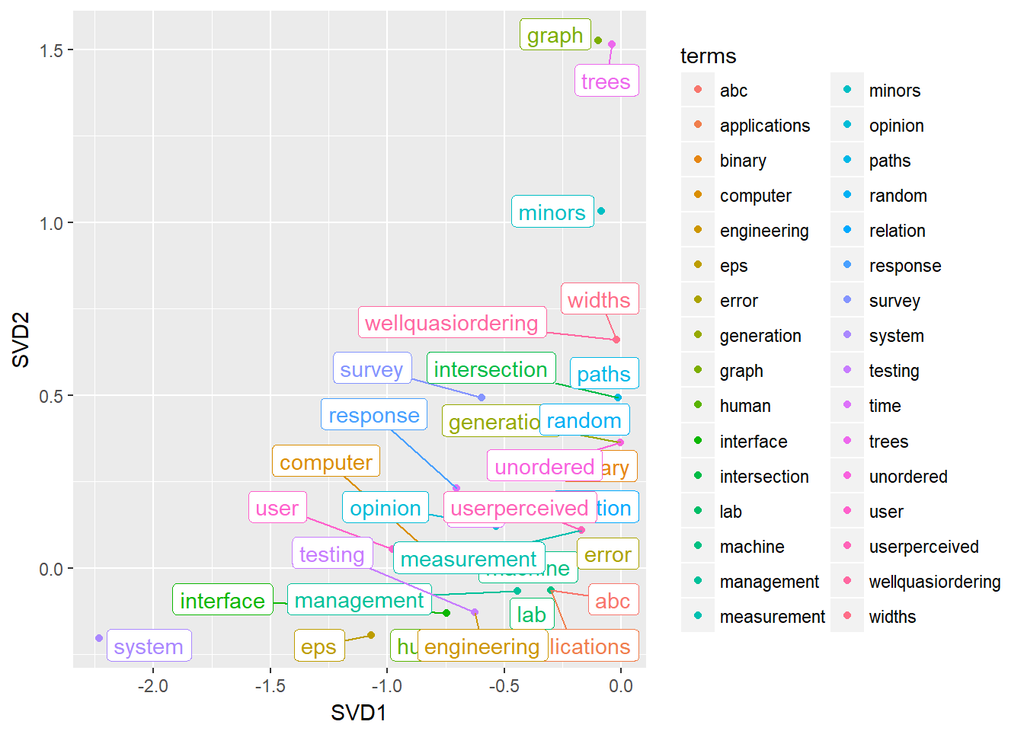

```r
data = data.frame(as.vector(Dictionary),vd )
colnames(data) = c("terms","SVD1","SVD2")
data$terms = as.character(data$terms)

ggplot(data, aes(SVD1,SVD2,color=terms)) + geom_point() +
  geom_label_repel (aes(label=terms),show.legend = FALSE)
```

So those words that are interelated to each other does end up closer together (Bottom left corner of graph being “Computer Systems”). And the more exclusive they are to the concept, the more they are placed further away from the other concepts.

So that concludes the first part. And now the most important task is to predict the next text. So here’s a sample text:

```r
############
# Predict new text
############
#Now for the final act, lets predict which topic this text below belongs to?
test = "Computer algorithms and Graph system, series 10: Elliot Dawson's algorithm through ensembling of decision trees"
test
```

```
## [1] "Computer algorithms and Graph system, series 10: Elliot Dawson's algorithm through ensembling of decision trees"
```

So, intuitively we know this text probably belongs to the Computer System concept. But it also does contain words from the “graph trees” as well. So its not exactly clear. Lets see how the algorithm works it out. Lets go ahead and do the standard data processing:

```r
# Standard text processing and cleaning
set = VCorpus((VectorSource(test)))  #use Vcorpus as there's a bug in indexing which results in incorrect line 151 below
set = tm_map(set, removeNumbers)
set = tm_map(set, removePunctuation)
set = tm_map(set, content_transformer(tolower))
set = tm_map(set, function(x) removeWords(x, stopwords("english")))
set = tm_map(set, stripWhitespace)
inspect(set[1])
```

```
## <<VCorpus>>
## Metadata:  corpus specific: 0, document level (indexed): 0
## Content:  documents: 1
##
## [[1]]
## <<PlainTextDocument>>
## Metadata:  7
## Content:  chars: 90
```

And now that its processed, we’ll coerce it into the Document-Term-Matrix, using the set Dictionary list. We don’t want extra words, just what matches the previous training dataset.

```r
# coerce the cleaned text into a proper NLP format, but this time using the restricted dictionary
dtm = DocumentTermMatrix(set,control = list(dictionary = Dictionary)) #need to make sure Vcorpus is used, or this part will be incorrect
as.matrix(dtm)
```

```
##     Terms
## Docs abc applications binary computer engineering eps error generation
##    1   0            0      0        1           0   0     0          0
##     Terms
## Docs graph human interface intersection lab machine management measurement
##    1     1     0         0            0   0       0          0           0
##     Terms
## Docs minors opinion paths random relation response survey system testing
##    1      0       0     0      0        0        0      0      1       0
##     Terms
## Docs time trees unordered user userperceived wellquasiordering widths
##    1    0     1         0    0             0                 0      0
```

We feed the fixed list of dictonary we compiled before. Let’s plot the results

```r
# foldin the eigen values from the previous run, to find out where this text fall under
test.mat = as.matrix(dtm)
test.mat %*% vd
```

```
##
## Docs      [,1]     [,2]
##    1 -1.735668 1.925837
```

So the document does end up getting classified into both “Computer Systems” concept, and the “Graph Trees” concept. Still not convinced? let’s visualise it again by plotting a scatter of the 2 dimensions for the documents this time (as opposed to words)

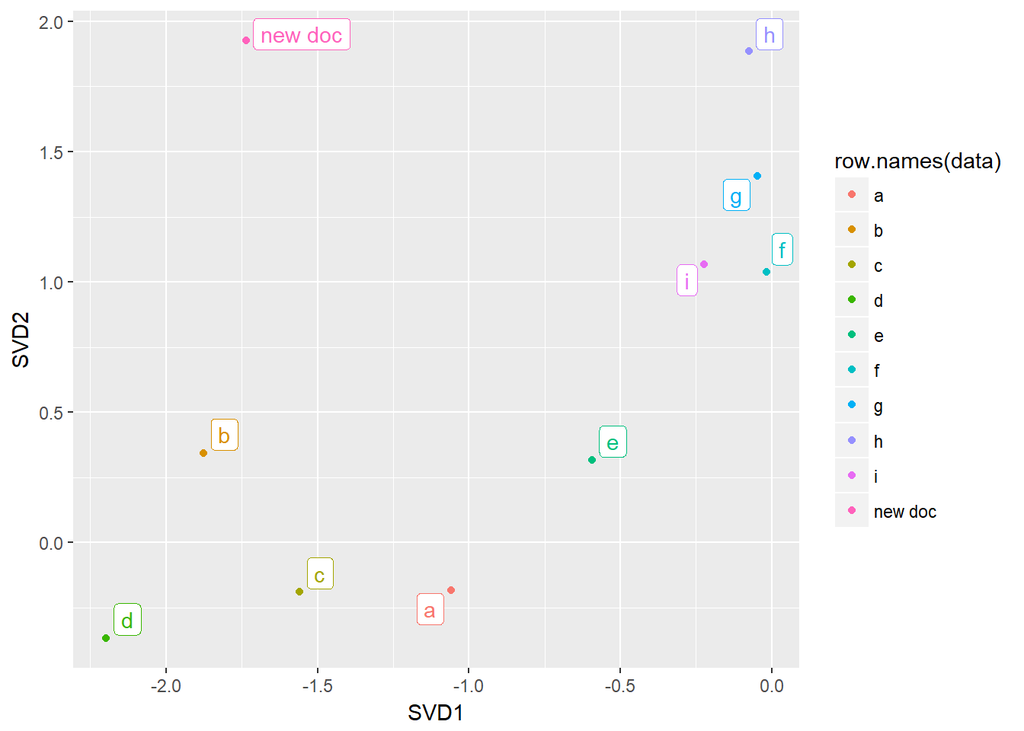

```r
#get the new foldin results
data = data.frame(test.mat %*% vd)

# Fold-in the U matrix to ensure consistency
data = rbind(data.frame(u %*% d),data)
row.names(data) = c('a','b','c','d','e','f','g','h','i','new doc')
colnames(data) = c("SVD1","SVD2")


ggplot(data, aes(SVD1,SVD2,color=row.names(data))) + geom_point() +
  geom_label_repel (aes(label=row.names(data)),show.legend = FALSE)
```

Since the text contains key words from 2 concepts, it ends up in its own space of both “Computer Systems” and “Graph Tree” concepts.